# World Edible Plants: Bayesian Assessment of Edibility

# Introduction

How many of the estimated 342,000 to 369,000 known vascular plant species are truly edible? Estimates vary wildly, with some suggesting fewer than 10,000 edible species, while others estimate as many as 30,000. This uncertainty reflects the complexity of defining edibility, influenced by cultural practices, biological factors, and processing requirements. This study aims to estimate the proportion of edible vascular plant species globally. While estimates vary from fewer than 7,000 to over 30,000 edible species, these numbers depend on definitions influenced by culture, toxicity, and available processing technologies.

This question mirrors a classic probability problem discussed by Douglas Hubbard in *How to Measure Anything*. Imagine a collection of urns, each containing a different mix of red and blue marbles. Without knowing the composition of any urn, how many marbles must you draw from one urn to estimate the proportion of red marbles within a certain confidence level? This analogy highlights the core of sampling uncertainty: how much data is needed before we can make reliable inferences about an entire population.

In this study, we apply this logic to plant edibility. We aim to estimate the true proportion of edible plant species using Bayesian inference and random sampling. Our approach incorporates different definitions of edibility and considers cultural practices and processing requirements.

We focus on a randomly selected sample of 200 plant species to assess edibility.

# Methods

## Defining Edibility Criteria

1. **Raw Edibility**: Whole plant edible raw (e.g., *Brassica oleracea*).
2. **Partial Edibility**: Parts of the plant are edible (e.g., apples).
3. **Processed Edibility**: Toxic unless processed (e.g., *Solanaceae* spp. or oak).

## Sample and Data Collection

The dataset contains 200 species, including 619 synonyms. Assuming a 10% population proportion of edible species, this sample size offers a 95% confidence interval with a ±4.16% margin of error.

### Literature Search Strategy

- **Search Queries**:
  - “species name” AND “food”
  - “species name” AND “edible”
- **Databases**:
  - Wikipedia (automated extraction)
  - Scopus (manual follow-up for unclassified species)

```r
# Placeholder: Assume initial unknown edibility status
species_data$edibility_status <- NA  # Will be updated after literature search

# Display initial dataset
head(species_data)
```

```
##         X        taxonID                   scientificNameID
## 1  657899 wfo-0000661872   urn:lsid:ipni.org:names:292636-1
## 2 1464893 wfo-1000012285                          100398786
## 3  254200 wfo-0000256782   urn:lsid:ipni.org:names:668556-1
## 4  420549 wfo-0000423561   urn:lsid:ipni.org:names:868749-1
## 5  310737 wfo-0000313379   urn:lsid:ipni.org:names:658401-1
## 6   25730 wfo-0000025163 urn:lsid:ipni.org:names:77083874-1
##                                    localID          scientificName taxonRank
## 1                                   911190   Echinopepon pubescens   species
## 2                                           Plagiochila hookeriana   species
## 3                               140159-wcs Oncosperma platyphyllum   species
## 4                                   597064           Viola najadum   species
## 5                                   194466   Spiranthes porrifolia   species
## 6 GCC-9C2E5A35-3071-4F06-BD96-D05EA60AFE62     Inuloides tomentosa   species
##   parentNameUsageID scientificNameAuthorship          family   subfamily
```

[output cut: 83 more lines]

# Bayesian Modeling of Edibility

## Bayesian Model Specification and Posterior Inference

This analysis utilizes several R packages for modeling and visualization. Specifically, we employ `brms` for Bayesian modeling (Bürkner (2024)), `bayesplot` for diagnostic visualization (Gabry and Mahr (2024)), `tidyverse` for data manipulation (Wickham (2023)), and `HDInterval` for computing highest density intervals (Meredith and Kruschke (2022)). These packages provide robust tools for implementing Bayesian hierarchical models and interpreting the resulting posterior distributions.

## Model Specification

```r
# Set non-informative priors
alpha_prior <- 1
beta_prior <- 1

# Placeholder values assuming future search updates
species_data$edibility <- ifelse(is.na(species_data$edibility_status), 0, 1)  # 1 for edible, 0 otherwise

total_edible <- sum(species_data$edibility)
total_species <- nrow(species_data)

# Posterior update
alpha_post <- alpha_prior + total_edible
beta_post <- beta_prior + total_species - total_edible

# Calculate credible intervals
credible_interval <- hdi(rbeta(10000, alpha_post, beta_post), credMass = 0.95)

list(
  mean_estimate = alpha_post / (alpha_post + beta_post),
  credible_interval = credible_interval
)
```

```
## $mean_estimate
## [1] 0.004950495
##
## $credible_interval
##        lower        upper
## 1.057780e-07 1.467544e-02
## attr(,"credMass")
## [1] 0.95
```

# Posterior Predictive Check

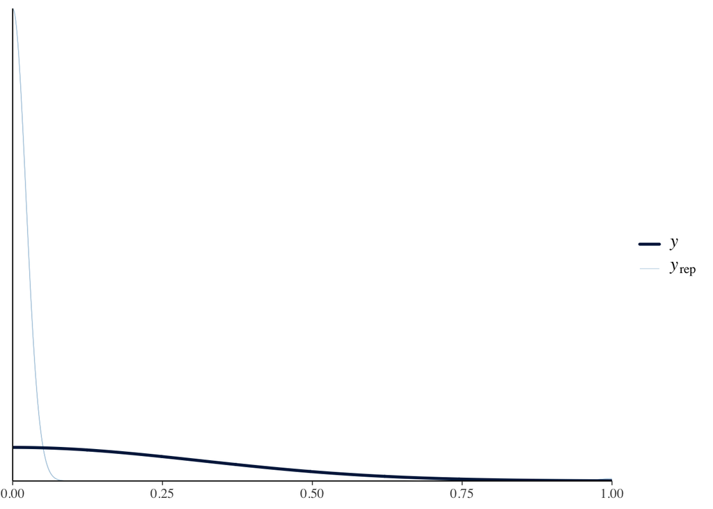

```r
# Diagnostic to assess model fit
pp_check(brm(edibility ~ 1, data = species_data, family = bernoulli()))
```

# References

Bürkner, Paul-Christian. 2024. *Brms: Bayesian Regression Models Using Stan*. https://github.com/paul-buerkner/brms.

Gabry, Jonah, and Tristan Mahr. 2024. *Bayesplot: Plotting for Bayesian Models*. https://mc-stan.org/bayesplot/.

Meredith, Mike, and John Kruschke. 2022. *HDInterval: Highest (Posterior) Density Intervals*. https://CRAN.R-project.org/package=HDInterval.

Wickham, Hadley. 2023. *Tidyverse: Easily Install and Load the Tidyverse*. https://tidyverse.tidyverse.org.